# ML Final Project

Nemin Dholakia

12/8/2021

##Import any necessary packages

1)Importing all necessary packages.

2)Read in the data as an .csv file

3)Display the head of the data (first 6 rows) so we can begin to understand what the dataset looks like.

```r
library(readr)     #For reading csv files
library(dplyr)     #For data wrangling
library(lubridate) #For handling dates
```

```r
library(ggplot2)   #For plotting of results

#Read in the data
Online_Retail <- read_csv("D:/MSBA/Fundamentals of Machine Learning/ML Final Project/Online_Retail.csv")
#Convert to dataframe
Online_Retail = data.frame(Online_Retail)
#Preview the data
head(Online_Retail)
```

```
##   InvoiceNo StockCode                         Description Quantity
## 1    536365    85123A  WHITE HANGING HEART T-LIGHT HOLDER        6
## 2    536365     71053                 WHITE METAL LANTERN        6
## 3    536365    84406B      CREAM CUPID HEARTS COAT HANGER        8
## 4    536365    84029G KNITTED UNION FLAG HOT WATER BOTTLE        6
## 5    536365    84029E      RED WOOLLY HOTTIE WHITE HEART.        6
## 6    536365     22752        SET 7 BABUSHKA NESTING BOXES        2
##      InvoiceDate UnitPrice CustomerID        Country
## 1 12/1/2010 8:26      2.55      17850 United Kingdom
## 2 12/1/2010 8:26      3.39      17850 United Kingdom
## 3 12/1/2010 8:26      2.75      17850 United Kingdom
## 4 12/1/2010 8:26      3.39      17850 United Kingdom
## 5 12/1/2010 8:26      3.39      17850 United Kingdom
## 6 12/1/2010 8:26      7.65      17850 United Kingdom
```

##Data Wrangling in dplyr 1)Remove any transactions that aren’t associated with a logged-in user (we can’t know how many purchases a user has made if they check out as a guest).

3)Transform the data from transactional level (the online retail dataframe) into customer-level (the customerlvl dataframe).

```r
#How many rows are not linked with a logged-in user?
sum(is.na(Online_Retail$CustomerID))
```

```
## [1] 135080
```

```r
#Answer: 135,080 transactions
#We will exclude these transactions, as we are only interested in monitoring user behaviour
Online_Retail <- Online_Retail %>%
  filter(!is.na(CustomerID))

#Ensure columns are of correct types
str(Online_Retail)
```

```
## 'data.frame':    406829 obs. of  8 variables:
##  $ InvoiceNo  : chr  "536365" "536365" "536365" "536365" ...
##  $ StockCode  : chr  "85123A" "71053" "84406B" "84029G" ...
##  $ Description: chr  "WHITE HANGING HEART T-LIGHT HOLDER" "WHITE METAL LANTERN" "CREAM CUPID HEARTS COAT HANGER" "KNITTED UNION FLAG HOT WATER BOTTLE" ...
##  $ Quantity   : num  6 6 8 6 6 2 6 6 6 32 ...
##  $ InvoiceDate: chr  "12/1/2010 8:26" "12/1/2010 8:26" "12/1/2010 8:26" "12/1/2010 8:26" ...
##  $ UnitPrice  : num  2.55 3.39 2.75 3.39 3.39 7.65 4.25 1.85 1.85 1.69 ...
##  $ CustomerID : num  17850 17850 17850 17850 17850 ...
##  $ Country    : chr  "United Kingdom" "United Kingdom" "United Kingdom" "United Kingdom" ...
```

```r
#In my offline version of the data (downloaded csv), I had to convert the invoice date column to a date column. Here, it looks like the correct
#datatypes have been preserved.

#Count number of unique items purchased by each customer
uniqueitems <- Online_Retail %>%
  group_by(CustomerID) %>%
  summarise(unique_items_customer = n_distinct(StockCode))

#Group the data at an invoice level
invoicelvl <- Online_Retail %>%
  group_by(CustomerID, InvoiceNo) %>%
  summarise(unique_items_inv = n(),
            quantity_purchased = sum(Quantity),
            total_price = sum(Quantity*UnitPrice),
            invoice_date = first(InvoiceDate)) %>%
  arrange(CustomerID,invoice_date)
#Join the two arrays together
combineddata <- left_join(invoicelvl, uniqueitems, by='CustomerID')

#Group the data at a customer level
customerlvl <- combineddata %>%
    group_by(CustomerID) %>%
    summarise(no_orders = n(),
              unique_items_purchased = min(unique_items_customer),
              quantity_items_purchased = sum(quantity_purchased),
              average_quantity_per_order = mean(quantity_purchased),
              total_money_spent = sum(total_price),
              average_spent_per_order = mean(total_price))
```

We now have all of the data we require to group the 4,372 users into clusters. A overview of the new dataset can be found here:

```r
summary(customerlvl[2:7])
```

```
##    no_orders       unique_items_purchased quantity_items_purchased
##  Min.   :  1.000   Min.   :   1.00        Min.   :  -303.0
##  1st Qu.:  1.000   1st Qu.:  15.00        1st Qu.:   153.0
##  Median :  3.000   Median :  35.00        Median :   365.0
##  Mean   :  5.075   Mean   :  61.21        Mean   :  1122.3
##  3rd Qu.:  5.000   3rd Qu.:  77.00        3rd Qu.:   962.2
##  Max.   :248.000   Max.   :1794.00        Max.   :196719.0
##  average_quantity_per_order total_money_spent  average_spent_per_order
##  Min.   : -244.0            Min.   : -4287.6   Min.   :-4287.6
##  1st Qu.:   78.0            1st Qu.:   293.4   1st Qu.:  152.0
##  Median :  137.0            Median :   648.1   Median :  237.0
##  Mean   :  196.8            Mean   :  1898.5   Mean   :  315.9
##  3rd Qu.:  232.2            3rd Qu.:  1611.7   3rd Qu.:  370.8
##  Max.   :12540.0            Max.   :279489.0   Max.   : 6207.7
```

The value of total money spent is substantially larger than the other columns. If we used k-means to the unscaled data right away, total money spent would dominate the other columns, and our customers would be categorized primarily by total money spent. The data must be scaled:

```r
#Scale the Data
km_data <- scale(customerlvl[2:7])
summary(km_data)
```

```
##    no_orders         unique_items_purchased quantity_items_purchased
##  Min.   :-0.436405   Min.   :-0.7048        Min.   :-0.30503
##  1st Qu.:-0.436405   1st Qu.:-0.5410        1st Qu.:-0.20744
##  Median :-0.222244   Median :-0.3068        Median :-0.16208
##  Mean   : 0.000000   Mean   : 0.0000        Mean   : 0.00000
##  3rd Qu.:-0.008082   3rd Qu.: 0.1848        3rd Qu.:-0.03426
##  Max.   :26.012519   Max.   :20.2843        Max.   :41.85864
##  average_quantity_per_order total_money_spent  average_spent_per_order
##  Min.   :-1.3726            Min.   :-0.75263   Min.   :-12.7437
##  1st Qu.:-0.3700            1st Qu.:-0.19528   1st Qu.: -0.4537
##  Median :-0.1862            Median :-0.15213   Median : -0.2184
##  Mean   : 0.0000            Mean   : 0.00000   Mean   :  0.0000
##  3rd Qu.: 0.1102            3rd Qu.:-0.03489   3rd Qu.:  0.1521
##  Max.   :38.4356            Max.   :33.77283   Max.   : 16.3100
```

##Reducing Dimensionality

In this step the following things would be done: 1)Check for multicollinearity.

2)Try to find principal components to see if the dimensionality can be reduced.

**Checking for multicollinearity**

```r
#Print correlation matrix
cor(km_data)
```

```
##                             no_orders unique_items_purchased
## no_orders                  1.00000000              0.6956634
## unique_items_purchased     0.69566343              1.0000000
## quantity_items_purchased   0.57416943              0.4409264
## average_quantity_per_order 0.04117428              0.1149862
## total_money_spent          0.56612197              0.4120146
## average_spent_per_order    0.08752532              0.1888894
##                            quantity_items_purchased average_quantity_per_order
## no_orders                                 0.5741694                 0.04117428
## unique_items_purchased                    0.4409264                 0.11498617
## quantity_items_purchased                  1.0000000                 0.31661947
## average_quantity_per_order                0.3166195                 1.00000000
## total_money_spent                         0.9216490                 0.23682905
## average_spent_per_order                   0.3816547                 0.61226503
##                            total_money_spent average_spent_per_order
## no_orders                          0.5661220              0.08752532
## unique_items_purchased             0.4120146              0.18888939
## quantity_items_purchased           0.9216490              0.38165474
## average_quantity_per_order         0.2368291              0.61226503
## total_money_spent                  1.0000000              0.42007813
## average_spent_per_order            0.4200781              1.00000000
```

Total_money_spent and quantity_items_purchased are highly co-related and we do not need both these variables in cluster analysis so I choose to remove total_money_spent.

```r
#Remove the 5th column & scale
km_data_reduced <- scale(customerlvl[c(2:5,7)])
summary(km_data_reduced)
```

```
##    no_orders         unique_items_purchased quantity_items_purchased
##  Min.   :-0.436405   Min.   :-0.7048        Min.   :-0.30503
##  1st Qu.:-0.436405   1st Qu.:-0.5410        1st Qu.:-0.20744
##  Median :-0.222244   Median :-0.3068        Median :-0.16208
##  Mean   : 0.000000   Mean   : 0.0000        Mean   : 0.00000
##  3rd Qu.:-0.008082   3rd Qu.: 0.1848        3rd Qu.:-0.03426
##  Max.   :26.012519   Max.   :20.2843        Max.   :41.85864
##  average_quantity_per_order average_spent_per_order
##  Min.   :-1.3726            Min.   :-12.7437
##  1st Qu.:-0.3700            1st Qu.: -0.4537
##  Median :-0.1862            Median : -0.2184
##  Mean   : 0.0000            Mean   :  0.0000
##  3rd Qu.: 0.1102            3rd Qu.:  0.1521
##  Max.   :38.4356            Max.   : 16.3100
```

**Checking for Principal Components**

```r
km_data.pca <- prcomp(km_data_reduced, center = T,scale = T)
#Summary of Principal Components
summary(km_data.pca)
```

```
## Importance of components:
##                           PC1    PC2    PC3     PC4     PC5
## Standard deviation     1.5533 1.2011 0.7158 0.62225 0.49526
## Proportion of Variance 0.4825 0.2885 0.1025 0.07744 0.04906
## Cumulative Proportion  0.4825 0.7710 0.8735 0.95094 1.00000
```

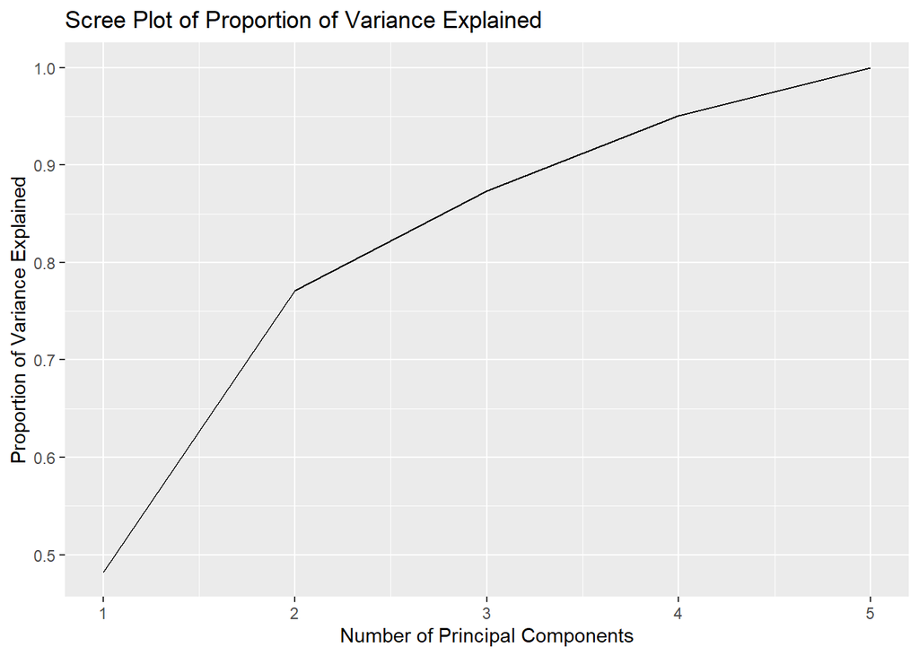

```r
#Proportion of variance explained:
var <- km_data.pca$sdev^2
pve <- var/sum(var)
#Scree Plot of Cumulative Variance Explained:
g <- qplot(x = 1:5, y = cumsum(pve), geom = 'line', xlab="Number of Principal Components", ylab='Proportion of Variance Explained', main="Scree Plot of Proportion of Variance Explained")
g + scale_x_continuous(breaks = seq(0, 5, by = 1))
```

##Applying K-means

**Identify the optimal number of clusters**

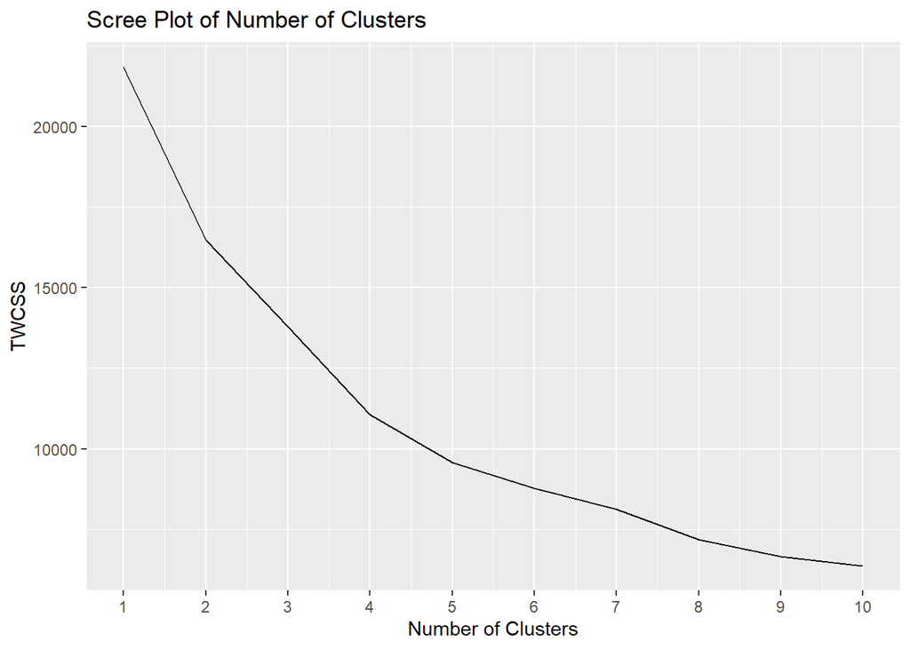

```r
#Remove randomness from iterations by setting a seed
set.seed(123)

#Determine the maximum number of clusters
#k_max = 10 means we will test all possible numbers of clusters from 1 to 10 to see which performs the best.
k_max <- 10

#Calculate the total within sum of squares for each of 1:k_max
twcss <- sapply(1:k_max, function(k){kmeans(km_data_reduced, k)$tot.withinss})
#Vizualize the results
g <- qplot(x = 1:k_max, y = twcss, geom = 'line', xlab="Number of Clusters", ylab='TWCSS', main="Scree Plot of Number of Clusters")
g + scale_x_continuous(breaks = seq(0, 10, by = 1))
```

We’re looking for a ‘elbow’ in the plot where the model’s quality no longer improves considerably as the model’s complexity grows. There is some ambiguity in this plan because there isn’t a defined elbow. This is due to a lack of separation between clusters (see the pairs plot below).

**Applying K-means clustering with 5 cluster**

```r
# k-means clustering
km <-kmeans(km_data_reduced, centers = 5, nstart=20)
#Check total within sum of squares with a variety of nstart and iter.max values
#to ensure algorithm convergence
km$tot.withinss
```

```
## [1] 9572.027
```

```r
#What are the characteristics of the 5 groups?
km$centers
```

```
##    no_orders unique_items_purchased quantity_items_purchased
## 1  1.2511948              1.5535037                0.4581963
## 2 -0.2030739             -0.2716794               -0.1471688
## 3  9.9718354              7.8008540               12.5302400
## 4 -0.3436019             -0.1374824                0.9231006
## 5 -0.1593412              0.1638137                0.2269996
##   average_quantity_per_order average_spent_per_order
## 1                0.007378346              0.05365236
## 2               -0.182832544             -0.23331610
## 3                2.530813432              3.89646370
## 4               10.408260674              8.83434582
## 5                1.198118802              1.62395165
```

```r
#How many users belong to each group?
table(km$cluster)
```

```
##
##    1    2    3    4    5
##  496 3480   15   15  366
```

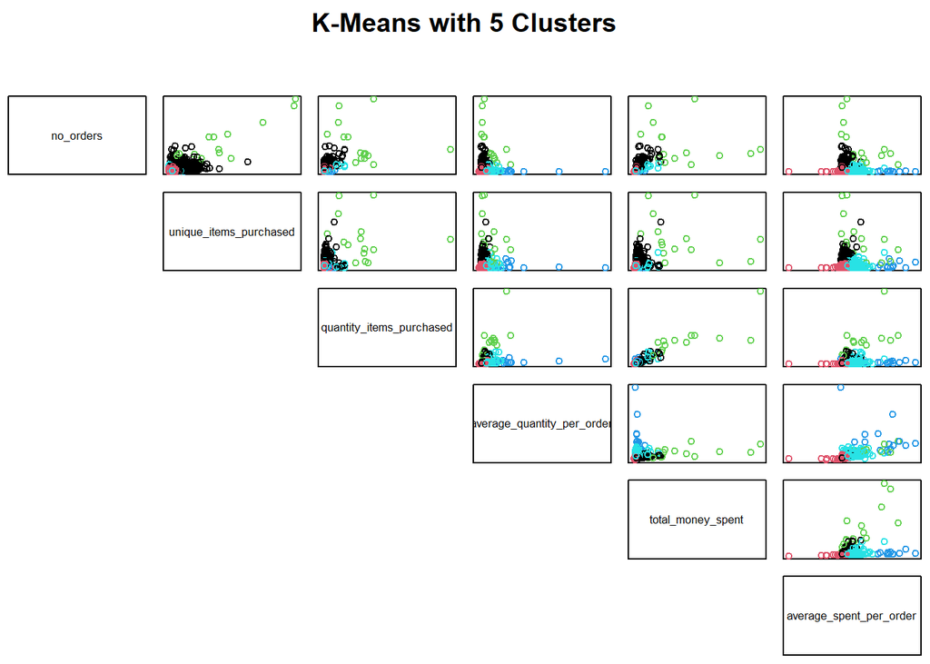

```r
# plot the dataset with clusters
par(pty="m")
pairs(km_data, col = km$cluster, main="K-Means with 5 Clusters", lower.panel=NULL,
      xaxt="n",yaxt="n", oma=c(0,0,5,0))
```

This scale is really hard to interpret - for example, category 2, where the ‘number of orders’ variable is centred around a negative number. Transforming centers back to original scale for added interpretability.

**Backtransform onto original scale of variables**

```r
data.orig = t(apply(km$centers, 1, function(r)r*attr(km_data_reduced,'scaled:scale') + attr(km_data_reduced, 'scaled:center')))
print(data.orig)
```

```
##   no_orders unique_items_purchased quantity_items_purchased
## 1 16.760081              193.91935                3263.3992
## 2  3.179023               38.00287                 434.6552
## 3 98.200000              727.60000               59673.5333
## 4  1.866667               49.46667                5435.8000
## 5  3.587432               75.20492                2183.0656
##   average_quantity_per_order average_spent_per_order
## 1                   199.1762                335.2646
## 2                   138.0920                231.6009
## 3                  1009.5511               1723.4314
## 4                  3539.3111               3507.1787
## 5                   581.5701                902.5153
```